# Zusammenhang zwischen Wortfolge und Wortstellung in den Nominalphrasen der Weltsprachen

Huan Wei, Master LinKoKo, Mart.-Nr. 2471884

2018-03-29

# 1. Einleitung

Insgesamt gibt es ca. 6500 bis 7000 Sprachen auf der Welt. Etwa die Hälfte der Erdbevölkerung spricht eine der 10 meistgesprochenen Sprachen. Diese sind Mandarin-Chinesisch, Englisch, Spanisch, Hindi, Arabisch, Portugiesisch, Bengali, Russisch, Japanisch und Deutsch.

Verschiedene Sprachen haben verschiedene Wortfolgenmöglichkeiten im Satz, zum Beispiel ist die Wortfolge im Deutschen Subjekt-Verb-Objekt, wie im Satz “Ich koche Suppe.”, im Japanischen ist die Wortfolge von diesem Satz jedoch Subjekt-Objekt-Verb: Watashi wa su-pu wo tsukuru Ich Suppe kochen

Verschiedene Sprachen haben verschiedene Wortstellungsmöglichkeiten in Nominalphrasen, zum Beispiel die Wortstellung von Adjektiven und Nomen in Nominalphrasen. Im Deutschen sthet das Adjektiv vor dem Nomen, wie in der Nominalphrase “das feuchte Holz”, aber im Französischen kann das Nomen vor das Adjektiv gestellt werden: Le bois humide das Holz feuchte

Jedoch kann man nicht sagen, dass die Sprachen auf der Welt keine Gemeinsamkeiten haben. Denn alle Sprachen haben Wörter und Sätze, Wörter werden aus elementaren bedeutungslosen Lauten oder Gesten gebildet, alle Sprachen haben komplexe morphologische und/oder syntaktische Strukturen, alle Sprachen haben Frageausdrücke und Verneinungsausdrücke usw.

Oft lassen sich universale Behauptungen nur dann aufstellen, wenn eine weitere Bedingung erfüllt ist: Implikationsuniversalien (vgl. Croft 2002). “Wenn eine Sprache L die Eigenschaft A hat, dann hat sie auch die Eigenschaft B”

Beispielsweise “Wenn eine Sprache einen [f] Laut hat, dann hat sie auch einen [s] Laut; Wenn in einer Sprache das Objekt dem Verb vorangeht”Der Hund die Katze jagt“, dann steht auch der Besitzer vor dem Besitz”des Hundes Hütte“.

Nach dieser Theorie wird in dieser empirischen Arbeit der Zusammenhangen zwischen den Wortfolgen im Satz und den Wortstellungen in Nominalphrasen von den erhobenen 26 Sprachen untersucht, und damit, ob es nach dieser Theorie auch Ausnahmen gibt und ob diese Zusammenhänge statistisch signifikant sind.

Diese Arbeit wurde mit Statistik “R” geschrieben und alle Daten wurden in “R” eingelesen und ausgewertet. Die Karten zu den Übersichten von verschiedenen Themen bezüglich der erhobenen Sprachen wurden mit “R” dargestellt.

# 2. Eigene empirische Arbeit

Um den Zusammenhangen zwischen der Wortfolge im Satz und den Wortstellungen in Nominalphrasen in der Sprache herauszufinden, wurde ein Fragebogen mit 10 deutschen Sätzen an verschiedene Muttersprachler gegeben. Von Dezember 2017 bis Ende Februar 2018 wurden insgesamt 25 Fragebogen von den Informanten beantwortet. Mit diesen 26 Sprachen (inklusive Deutsch) wurden die Implikationsuniversalien genau angeschaut.

## 2.1 Überlegungen zur Wahl der Informanten und Sprachen

Die Überlegungen zur Wahl der Personen war, dass nur die Muttersprachler einzubeziehen. Denn die L2-Lerner sind meistens unsicher und brauchen Lehrbücher oder ein Wörterbuch, um den Übersetzungsbogen in andere Sprachen zu übersetzen. Aber Muttersprachler können in der Regel die passenden Ausdrücke in ihrer Muttersprache problemlos finden.

Es ist beim Erheben optimal, wenn man die Sprachen von vielen Sprachfamilien als Quellen bekommen kann, am besten auch ein paar isolierte Sprachen oder die Sprachen mit wenigen Sprechern. Die untersuchten Sprachen sind: Deutsch, Englisch, Niederländisch, Französisch, Italienisch, Griechisch, Portugiesisch, Polnisch, Russisch, Ukrainisch, Rumänisch, Armenisch, Türkisch, Tigrinja, Hindi, Vietnamesisch, Indonesisch, Kroatisch, Georgisch, Berber, Persisch und mexikanisches Spanisch.

Obwohl nur 26 Sprachen erhoben wurde, sind diese Sprachen gut in Sprachfamilien aufgeteilt. Es gibt nicht nur Indoeuropäische Sprachen wie Deutsch, Englisch, Niederländisch, Französisch, Spanisch, Italienisch, Griechisch, Portugiesisch, Polnisch, Russisch, Ukrainisch, Rumänisch, Hindi, Kroatisch und Persisch, sondern auch isolierten Sprachen wie Koreanisch, Japanisch und Chinesisch. Außerdem sind Altaische Sprachen wie Türkisch, Afroasiatische Sprachen wie Tigrinja und Berber, Sinotibetische Sprachen wie Kantonesisch, Austroasiatische Sprache wie Vietnamesisch, Austronesisch wie Indonesisch und Südkaukasische Sprachen wie Georgisch dabei (vgl. Wals.info).

Im Folgenden werden die Daten von den erhobenen Sprachen in “R” eingelesen und anschließend wird mit diesen Daten eine Karte zur Übersicht der erhobenen Sprachen dargestellt.

Die Analyse der erhobenen Sprachen ist als “Umfragedaten.csv” im Ordner “sources” gespeichert. Hier wird es mit “read.csv()” in R eingelesen und “Daten” genannt. Mit der Funktion “summary()” kann man die Strukturen von der Datei anschauen.

```r
Daten <- read.csv ("//Users/verawei/Desktop/HA Sprachtypologie/sources/Umfragedaten.csv"
                    , header = TRUE
                   , sep = ";")
```

```r
summary(Daten)
```

```
        Sprache                 Land        Gattung              Familie
 Armenisch  : 1   China           : 2   Romance : 5   Indoeuropäisch :16
 Berber     : 1   Iran            : 2   Slavic  : 4   Afroasiatisch  : 2
 Chinesisch : 1   Deutschland     : 1   Germanic: 3   Altaisch       : 1
 Deutsch    : 1   England         : 1   Armenian: 1   Austroasiatisch: 1
 Englisch   : 1   Ethiopia Eritrea: 1   Berber  : 1   Austronesisch  : 1
 Französisch: 1   Frankreich      : 1   Chinese : 1   Chinesisch     : 1
 (Other)    :20   (Other)         :18   (Other) :11   (Other)        : 4
    Latitude       Longitude      Wortfolge          Adjektiv.Nomen
 Min.   : 0.00   Min.   :-99.38   SOV: 6    Adj+N           :17
 1st Qu.:32.17   1st Qu.: 10.50   SVO:20    N+Adj           : 7
 Median :39.00   Median : 34.00             No domiant order: 2
 Mean   :36.66   Mean   : 41.68
 3rd Qu.:47.50   3rd Qu.: 71.25
 Max.   :56.00   Max.   :140.00

     Musik.Mozart    Artikel.Nomen Farbe.Nomen Numeral.Nomen    Artikel.Farbe
 MoMu      : 9    DET+N     :23    Fa+N:18     Num+N:26      DET+Fa    :18
 MuMo      :15    N+DET     : 2    N+Fa: 8                   Fa+DET    : 1
 nicht klar: 2    nicht klar: 1                              nicht klar: 7




   Artikel.Numeral   Artikel.Adjektiv Farbe.Adjektiv Adjektiv.Adjektiv.Umfang
 DET+Num   :21     Adj+DET   : 2      Adj+Fa:20      Adj-U+Adj : 8
 nicht klar: 1     DET+Adj   :22      Fa+Adj: 6      Adj+Adj-U :16
 Num+DET   : 4     nicht klar: 2                     nicht klar: 2
```

Mit der Darstellung kann man die Strukturen der Analysedatei klar verstehen. Die erste Spalte der Datei sind die 26 erhobenen Sprachen und das erste Ziel von der Datei sind die 17 Verteilungen: “Sprache”, “Land”, “Gattung”, “Familie”, “Latitude”, “Longitude”, “Wortfolge”, “Adjektiv + Nomen”, “Musik + Mozart”, “Artikel + Nomen”, “Farbe + Nomen”, “Numerale + Nomen”, “Artikel + Farbe”, “Artikel + Numerale”, “Artikel + Adjektiv”, “Farbe + Adjektiv” und “Adjektiv + Adjektiv_Umfang”.

#### Karte 1: Übersicht der erhobenen Sprachen

In Karte 1 werden alle erhobenen Sprachen nach ihrer räumlichen Verteilung auf der Weltkarte dargestellt. Die Karte 1 zeigt, dass die erhobenen Sprachen gut auf der ganzen Welt verteilt sind. Die meisten Sprachen sind europäische Sprachen, aber asiatische und afrikanische Sprachen sind auch dabei.

```r
library(maps)
map("world", interior=FALSE, col="grey", resolution=0)
points(Daten$Longitude, Daten$Latitude
       , col = "red"
       , cex =.7
       , pch = 20)
```

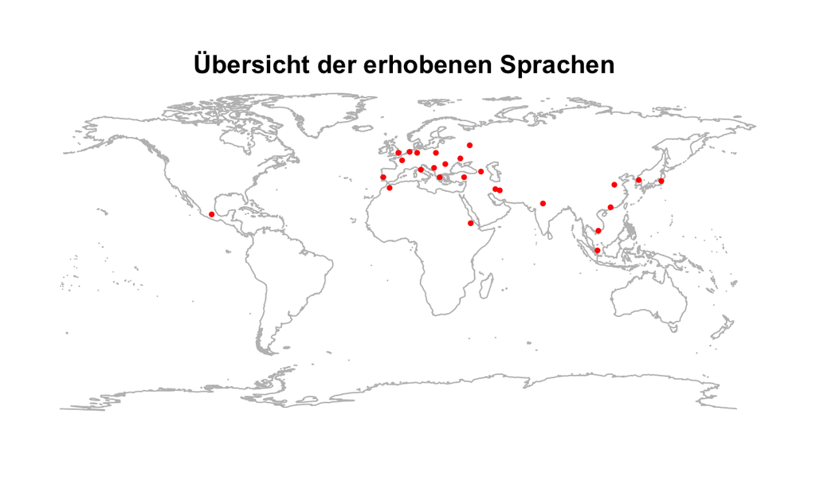

```r
title (main = "Übersicht der erhobenen Sprachen ")
```

#### Karte 2: Übersicht der erhobenen Sprachen nach der Sprachfamilie

In der darauffolgenden Karte 2 werden diese erhobenen Sprachen nach ihrer Sprachfamilie dargestellt. Mit dieser Darstellung kann man einen besseren Überblick über die Sprachen und ihre zugehörige Sprachfamilie bekommen. Die erhobenen Sprachen sind gut in Sprachfamilien aufgeteilt.

```r
table(Daten$Familie)
```

```
  Afroasiatisch        Altaisch Austroasiatisch   Austronesisch      Chinesisch
              2               1               1               1               1
 Indoeuropäisch       Japanisch      Koreanisch   Sinotibetisch   Südkaukasisch
             16               1               1               1               1
```

Mit der Funktion “table()” bekommt man die Verteilung der Datei in “R”. Es zeigt, dass es in der vorliegenden Untersuchung insgesamt 16 Indoeuropäische Sprachen und zwei Afroasiatische Sprachen gibt. Außerdem sind die Sprachfamilien Südkaukasische Sprachen, Altaische Sprachen, Austroasiatische Sprachen, Austronesische Sprache, Sinotibetische Sprachen, Chinesisch, Japanisch und Koreanisch auch dabei. Darüber hinaus kann man sagen, dass die erhobenen 26 Sprachen sehr vielfältig sind.

```r
maps::map("world"
          ,interior = FALSE
          , col = "grey"
          , resolution = 0)
cols <- c("darkgreen", "blue", "yellowgreen", "gold", "purple", "red", "deepskyblue2", "darkblue", "darkorchid1", "green3")
mycols <- cols[Daten$Familie]
mysymbols <- c(20, 20, 20, 20, 20, 20, 20, 20, 20, 20)
Sprachefamilie <- mysymbols[Daten$Familie]
myname <- c("Afroasiatisch", "Altaisch", "Austroasiatisch", "Austronesisch", "Chinesisch", "Indoeuropäisch", "Japanisch", "Koreanisch", "Sinotibetisch", "Südkaukasisch")
points(Daten$Longitude, Daten$Latitude
       , pch = Sprachefamilie
       , col = mycols
       )
```

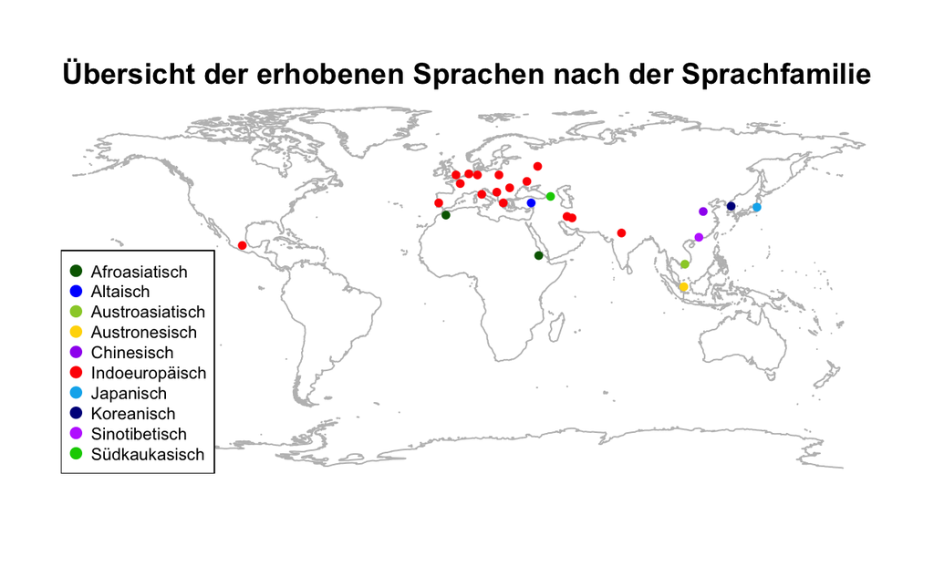

```r
title(main = "Übersicht der erhobenen Sprachen nach der Sprachfamilie")
legend ("bottomleft"
        , legend = myname
        , pch = Sprachefamilie
        , col = cols
        , cex = 0.7
        , pt.cex = 1.5)
```

Um die Struktur der Sprachen mit Farben darzustellen, habe ich zuerst mit der Funktion “table()” die Struktur der Sprachfamilie angeschaut, sodass ich die richtige Reihenfolge der Sprachen mit passenden Farben einordnen konnte. Die Auswahl von Farben für die Karte ist schwierig. Einerseits sollten die eng zusammengehörigen Sprachfamilien eine ähnliche Farbe bekommen, andererseits sollten die Ortspunkte von Sprachen gut auffällig sind.

## 2.2 Zu übersetzende Sätze

Dieser Übersetzungsbogen wurde von mir und zwei weiteren Studentinnen zusammengestellt. Mit diesem Übersetzungsbogen möchten wir herausfinden, wie bestimmte Sätze in verschiedene Sprachen aufgebaut sind, wie Superlativ und Modalpartikeln. Daher enthält der Übersetzungsbog folgende zehn Sätze:

- 1. Ich koche Suppe.
- 2. Der Bäcker backt ja das Brot am schnellsten.
- 3. Die Schüler hören am liebsten Musik von Mozart.
- 4. Die Touristen sehen diese fünf großen Häuser.
- 5. Die Kinder werfen doch einen schönen großen roten Ball.
- 6. Was machst du denn?
- 7. Du hast eben nicht genug gelernt!
- 8. Tim wirft den Ball am weitesten.
- 9. Kleine Hunde bellen aber am lautesten.
- 10. Das feuchte Holz verbrennt am schlechtesten.

Ich interessiere mich für den Zusammenhang zwischen den Wortfolgen und den Wortstellungen in Nominalphrasen der Sprachen. Für meine Analyse sind nur folgende Satzteile relevant:

- vom ersten Satz: Ich koche Suppe. [Subjekt + Verb + Objekt]
- vom dritten Satz: Musik von Mozart [ Nomen + Nomen]
- vom vierten Satz: diese fünf großen Häuser [DET + Num + Adj-Umfang + N]
- vom fünften Satz: einen schönen großen roten Ball [ ART + Adj + Adj-Umfang + Farbe + N]
- vom neunten Satz: kleine Hunde [Adj + N]
- vom zehnten Satz: das feuchte Holz [DET + Adj + N]

Mit Satz 1 möchte ich die Wortfolgen im Satz der jeweiligen Sprache festzustellen. Leider gibt es viele Sprachen, in denen das Subjekt im Satz wegfällt, wenn es “ich” ist, und wird mit der Verbendung markiert. Daher habe ich die Wortfolgen von der Sprache immer für alle gefragten zehn Sätzen berücksichtigt.

Mit der Phrase “Musik von Mozart” wird die Genitiv-Nomen-Reihenfolge analysiert, damit wird die Reihenfolge für Genitiv-Nomen oder Nomen-Genitiv in der Sprache festgestellt. Mit den Satzteilen von Sätzen 4, 5, 9, 10 werden die Reihenfolgen von verschiedenen Elementen in der Nominalphrase der erhobenen Sprachen festgestellt.

Außerdem sind die Nominalphrasen der Sätze 3, 4 und 5 das direkte Objekt, aber im Satz 9 und 10 sind die Nominalphrasen das Subjekt. Die Analyse der erhobenen Sprachen zeigt keine Unterschieden in der Wortstellung in Nominalphrasen von diesen fünf Sätzen (siehe Daten von “Umfrage Analyse.xlsx”).

## 2.3 Methode und Ablauf

Die meisten Informanten sind meine Arbeitskollegen, Freunde oder Kommilitonen. Durch persönliche Gespräche, E-Mails und Nachtrichten von Facebook habe ich sie als Informanten gewonnen. Die Übersetzungsbögen wurden entweder in Papierformen den Informanten persönlich gegeben, oder als Word- und PDF-Datei an Informanten per E-Mail verschickt. Die Informanten haben durchschnittlich ca. eine Woche gebraucht, bis sie mir die Übersetzungen zurückgeben konnten.

Für Sprachen wie Kroatisch, Armenisch und Rumänisch hatten die Informanten die Fragebögen an Freunde weitergeleitet. Zusammenfassend kann man sagen, dass Enkodierung der Informanten nicht sehr schwierig war. Denn sie sind sehr motiviert, ihre Muttersprache anderen zu erklären und die Unterschiede zwischen ihrer Muttersprache und Deutsch besser zu erkennen.

# 3. Ergebnisse der Umfrage

Die Ergebnisse der Umfragesätze sind zuerst nach Sprache analysiert. Die Wortfolge in Sätzen und die Wortstellung in Nominalphrasen sind für jede Sprache sehr genau berücksichtigt. Die Ergebnisse sind als Excel-Datei “Umfrage Analyse” im Ordner “sources” zu finden.

Für die Analyse in R wird die Excel-Datei “Daten_Umfrage” genutzt. In dieser Analyse sind die Sprachen nach Land, Gattung und Familie zuerst berücksichtigt. Außerdem sind Longitude und Latitude von der jeweiligen Sprache nach Wals.info für das Erstellen der Karte berücksichtigt. Die Analyse von Daten ist außer bezüglich Wortfolge in sehr viele kleine Elementpaare unterteilt, wie “Adjektiv + Nomen”, “Musik + Mozart”, “Artikel + Nomen”, “Farbe + Nomen”, “Numerale + Nomen”, “Artikel + Farbe”, “Artikel + Numerale”, “Artikel + Adjektiv”, “Farbe + Adjektiv” und “Adjektiv + Adjektiv-Umfang”.

Im Folgenden wird nicht nur die Verteilung der Wortfolge von Subjekt, Objekt und Verb der erhobenen Sprachen in Weltkarte dargestellt, sondern auch die Wortstellungen in Nominalphrasen und die Reihenfolge von verschiedenen Arten der Adjektive in der Nominalphrase der erhobenen Sprachen.

## 3.1 Die Wortfolge von Subjekt, Objekt und Verb der erhobenen Sprachen

Für die Wortfolgen von Subjekt, Objekt und Verb wird nicht nur Satz 1 “Ich koche Suppe” analysiert, sondern auch alle weiteren neun Sätze aus dem Umfragebogen.

#### Karte 3: Die Wortfolge von Subjekt, Objekt und Verb der erhobenen Sprachen

```r
table(Daten$Wortfolge)
```

```
SOV SVO
  6  20
```

Mit der Funktion “table()” können wir die Verteilung der Wortfolge der erhobenen Sprachen sehen. Unter diesen Sprachen gibt es insgesamt sechs Sprachen, die eine “Subjekt-Objekt-Verb (SOV)”-Wortfolge haben und insgesamt 20 Sprachen, die eine “Subjekt-Verb-Objekt (SVO)”- Wortfolge haben.

```r
maps::map("world"
          ,interior = FALSE
          , col = "grey"
          , resolution = 0)
cols <- c("blue", "red")
mycols <- cols[Daten$Wortfolge]
mysymbols <- c(20, 20)
Wortfolge <- mysymbols[Daten$Wortfolge]
freq <- table(Daten$Wortfolge)
myname <- c(
      paste0("SOV-Sprache (", freq[1], ")")
    , paste0("SVO-Sprache (", freq[2], ")")
    )
points(Daten$Longitude, Daten$Latitude
       , pch = Wortfolge
       , col = mycols)
```

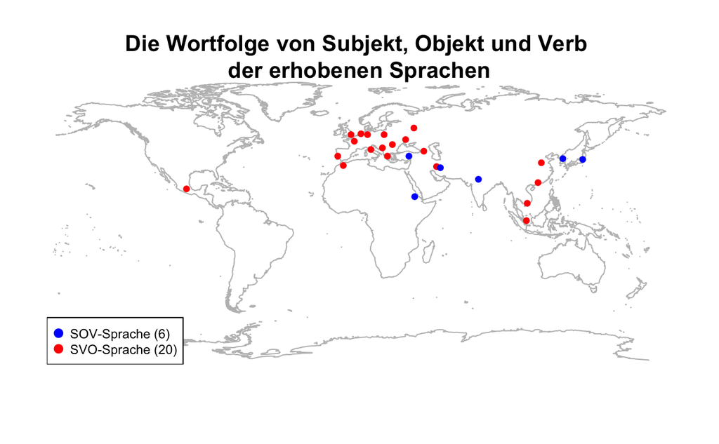

```r
title(main = "Die Wortfolge von Subjekt, Objekt und Verb
der erhobenen Sprachen")
legend ("bottomleft"
        , legend = myname
        , pch = Wortfolge
        , col = cols
        , cex = 0.7
        , pt.cex = 1.5)
```

Auf Karte 3 “Die Wortfolge von Subjekt, Objekt und Verb der erhobenen Sprachen” sind alle 6 SOV-Sprache in blauen Pünktchen und alle 20 SVO-Sprache in roten Pünktchen auf der Weltkarte dargestellt. Diese Karte gibt einen guten Überblick über die Verteilung der Wortfolgen von allen erhobenen Sprachen.

## 3.2 Die Wortstellungen in den Nominalphrasen der erhobenen Sprachen

Um die Wortstellungen in den Nominalphrasen zu untersuchen, werden die Elemente immer in Pärchen verglichen und dargestellt: die Reihenfolge von Adjektiv und Nomen in der Nominalphrase, die Reihenfolge von Artikel und Nomen in der Nominalphrase, die Reihenfolge von Farbe und Nomen in der Nominalphrase, die Reihenfolge von Numerale und Nomen in der Nominalphrase und die Reihenfolge von Genitiv und Nomen in der Nominalphrase.

Außerdem werden die Wortstellungen von den verschiedenen Arten der Adjektive in der Nominalphrase auch dargestellt: die Reihenfolge von Artikel und Farbe, die Reihenfolge von Artikel und Numerale, die Reihenfolge von Artikel und Adjektiv, die Reihenfolge von Farbe und Adjektiv und die Reihenfolge von Adjektiv und Umfangsadjektiv in Nominalphrasen.

### 3.2.1 Die Reihenfolge von Adjektiv und Nomen in der Nominalphrase

Um die Reihenfolge von Adjektiv und Nomen von den erhobenen Sprachen festzulegen, wurden diesen Satzteilen berücksichtigt: “große Häuser”, “schönen großen Ball”, “kleine Hunde” und “feuchtes Holz”. Nur wenn die Reihenfolge von Adjektiv und Nomen in diesen vier Satzteilen identisch ist, wurde die Reihenfolge von Adjektiv und Nomen in der Nominalphrase der Sprache bestimmt.

```r
table(Daten$Adjektiv.Nomen)
```

```
           Adj+N            N+Adj No domiant order
              17                7                2
```

Mit Funktion “table()” sehen wir, dass insgesamt 17 Sprachen die Reihenfolge “Adjektiv vor dem Nomen” in der Nominalphrase haben, und 7 Sprachen die Reihenfolgen “Nomen vor dem Adjektiv”. Außerdem gibt es zwei Sprachen, nämlich Französisch und Indonesisch, ohne dominante Reihenfolge von Adjektiv und Nomen in der Nominalphrase.

#### Karte 4: Die Reihenfolge von Adjektiv und Nomen in der Nominalphrase

```r
maps::map("world"
          ,interior = FALSE
          , col = "grey"
          , resolution = 0)
cols <- c("red", "blue", "green3")
mycols1 <- cols[Daten$Adjektiv.Nomen]
mysymbols <- c(20, 20, 20)
AdjNon <- mysymbols[Daten$Adjektiv.Nomen]
myname <- c("Adjektiv vor Nomen (17)", "Nomen vor Adjektiv (7)", "Beides (2)")
points (Daten$Longitude, Daten$Latitude
       , pch = AdjNon
       , col = mycols1)
```

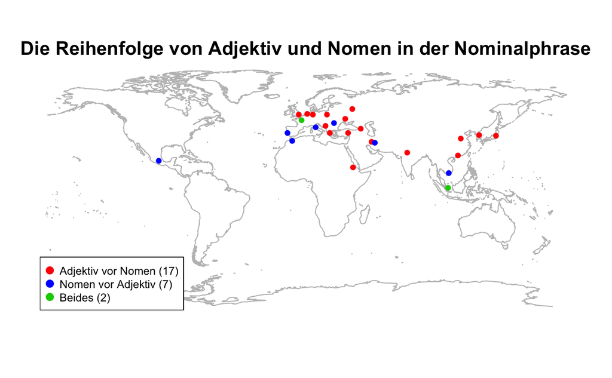

```r
title(main = "Die Reihenfolge von Adjektiv und Nomen in der Nominalphrase")
legend ("bottomleft"
        , legend = myname
        , pch = AdjNon
        , col = cols
        , cex = 0.7
        , pt.cex = 1.5)
```

Auf der Karte 4 “Die Reihenfolge von Adjektiv und Nomen in Nominalphrase” werden die 17 Sprachen mit der Reihenfolge “Adjektiv vor Nomen” in roten Pünktchen markiert und 7 Sprachen mit der Reihenfolge “Nomen vor Adjektiv” in blauen Pünktchen markiert. Mit grünen Pünktchen sind Französischen und Indonesischen markiert.

Im Französischen ist die Reihenfolge von Adjektiv und Nomen in Nominalphrase nicht immer gleich, wie zum Beispiel: - Artikel + Adjektiv + Nomen (als Subjekt) - les petits chiens - die kleinen Hunde

- Artikel + Nomen + Adjektiv (als Subjekt)
- le bois humide
- das Holz feuchte

Im Indonesischen ändert sich die Reihenfolge von Adjektiv und Nomen in der Nominalphrase auch immer wieder, beispielsweise: - Nomen + Adjektiv + Artikel - rumah besar ini - Häuser groß das

- Adjektiv + Nomen
- kecil anjing
- klein Hund

Dadurch dass die Reihenfolge von Adjektiv und Nomen in der Nominalphrase für Französischen und Indonesischen beide Optionen möglich sind, wurden der Typ dieser Reihenfolge hier als “Beides” auf der Karte gestellt.

### 3.2.2 Die Reihenfolge von Artikel und Nomen in der Nominalphrase

Die Wortstellung in den Nominalphrasen “diese fünf großen Häuser” und “das feuchte Holz” wurden für die Festlegung der Reihenfolge von Artikel und Nomen in der Nominalphrase angeschaut. Nur wenn die Reihenfolgen von diesen zwei Nominalphrasen identisch sind, kann man ihre Reihenfolge festlegen.

```r
table(Daten$Artikel.Nomen)
```

```
     DET+N      N+DET nicht klar
        23          2          1
```

Durch die Funktion “table()” sieht man, dass insgesamt 23 Sprachen eine Reihenfolge “Artikel vor Nomen” haben und nur in zwei Sprachen “Nomen vor Artikel” steht. In dem Übersetzungsbogen von Persisch gab es leider keinen Artikel, daher wurde diese Reihenfolge für Persischen als “nicht klar” dargestellt.

#### Karte 5: Die Reihenfolge von Artikel und Nomen in der Nominalphrase

```r
maps::map("world"
          ,interior = FALSE
          , col = "grey"
          , resolution = 0)
cols <- c("red", "blue", "green3")
mycols2 <- cols[Daten$Artikel.Nomen]
mysymbols <- c(20, 20, 20)
ArtNon <- mysymbols[Daten$Artikel.Nomen]
myname <- c("Artikel vor Nomen (23)", "Nomen vor Artikel (2)", "Nicht Klar (1)")
points (Daten$Longitude, Daten$Latitude
       , pch = ArtNon
       , col = mycols2)
```

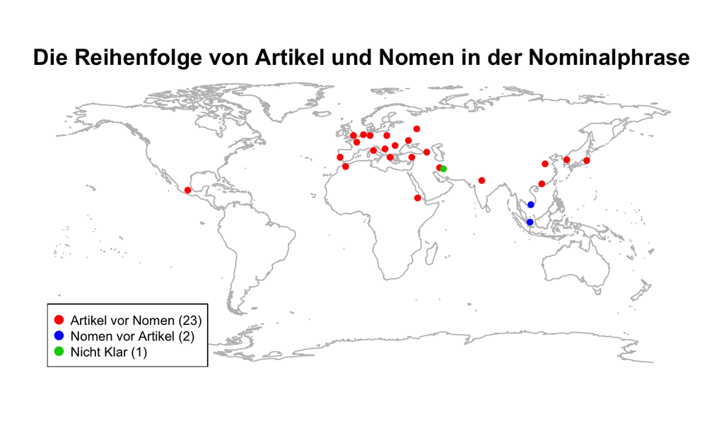

```r
title(main = "Die Reihenfolge von Artikel und Nomen in der Nominalphrase")
legend ("bottomleft"
        , legend = myname
        , pch = ArtNon
        , col = cols
        , cex = 0.7
        , pt.cex = 1.5)
```

In Karte 5 sehen wir, dass die dominante Reihenfolge von Artikel und Nomen der erhobenen Sprachen “Artikel vor Nomen” ist. Jedoch gibt es noch zwei Sprachen. Vietnamesisch und Indonesisch, in denen die Reihenfolge “Nomen vor Artikel” dominiert. Wie in der Nominalphrase “diese fünf großen Häuser”:

- Im Vietnamesischen:
- Numerale + Nomen + Adjektiv + Artikel
- năm ngôi nhà lớn này
- fünf Häuser großen dies
- In Indonesischen:
- Numerale + Nomen + Adjektiv + Artikel
- lima rumah besar ini
- fünf Häuser groß das

### 3.2.3 Die Reihenfolge von Farbe und Nomen in der Nominalphrase “roter Ball”

Die Reihenfolge von Farbe und Nomen wurde nur mit “rot + Ball” in der Nominalphrase “einen schönen großen roten Ball” berücksichtigt.

```r
table(Daten$Farbe.Nomen)
```

```
Fa+N N+Fa
  18    8
```

Trotzdem ergibt sich eine klare Unterschieden unter den Sprachen, es gibt insgesamt 18 Sprachen mit der Reihenfolge “Farbe + Nomen” und 8 Sprachen “Nomen + Farbe”.

#### Karte 6: Die Reihenfolge von Farbe und Nomen in der Nominalphrase: roter Ball

```r
maps::map("world"
          ,interior = FALSE
          , col = "grey"
          , resolution = 0)
cols <- c("red", "blue")
mycols3 <- cols[Daten$Farbe.Nomen]
mysymbols <- c(20, 20)
FarbNon <- mysymbols[Daten$Farbe.Nomen]
myname <- c("Farbe vor Nomen (18)", "Nomen vor Farbe (8)")
points (Daten$Longitude, Daten$Latitude
       , pch = FarbNon
       , col = mycols3)
```

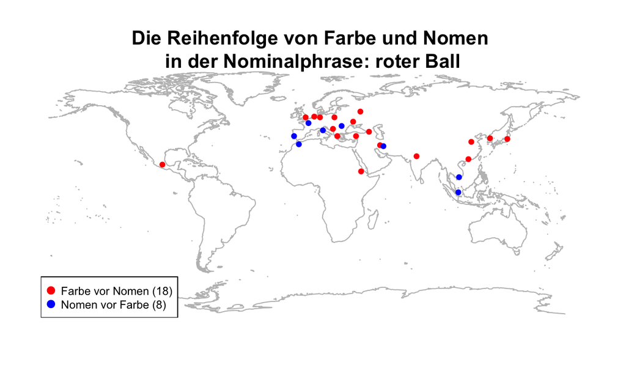

```r
title(main = "Die Reihenfolge von Farbe und Nomen
in der Nominalphrase: roter Ball")
legend ("bottomleft"
        , legend = myname
        , pch = FarbNon
        , col = cols
        , cex = 0.7
        , pt.cex = 1.5)
```

Auf Karte 6 “Die Reihenfolge von Farbe und Nomen in der Nominalphrase: roter Ball” sind die 18 Sprachen für “Farbe vor Nomen” mit roten Pünktchen markiert und mit blauen Pünktchen die Sprachen mit “Nomen vor Farbe”.

### 3.2.4 Die Reihenfolge von Numeralen und Nomen in der Nominalphrase “fünf Häuser”

Die Reihenfolge von Numerale und Nomen in der Nominalphrase wurde nur durch die Wortstellung in “diese fünf großen Häuser” festgelegt. Hier gibt es keine Ausnahme, alle erhobenen 26 Sprachen haben die Reihenfolge “Numerale vor Nomen”.

```r
table(Daten$Numeral.Nomen)
```

```
Num+N
   26
```

#### Karte 7: Die Reihenfolge von Numerale und Nomen in der Nominalphrase: fünf Häuser

```r
maps::map("world"
          ,interior = FALSE
          , col = "grey"
          , resolution = 0)
cols <- c("blue", "red")
mycols4 <- cols[Daten$Numeral.Nomen]
mysymbols <- c(20)
NumNon <- mysymbols[Daten$Numeral.Nomen]
myname <- c("Numerale vor Nomen (26)", "Nomen vor Numerale (0)")
points (Daten$Longitude, Daten$Latitude
       , pch = NumNon
       , col = mycols4)
```

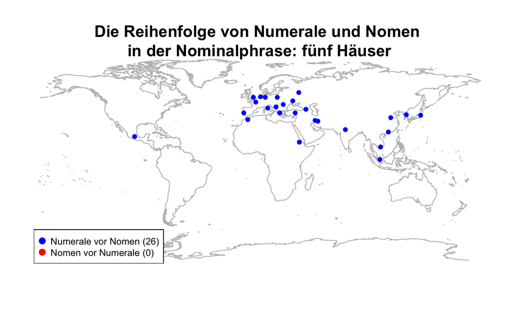

```r
title(main = "Die Reihenfolge von Numerale und Nomen
in der Nominalphrase: fünf Häuser")
legend ("bottomleft"
        , legend = myname
        , pch = NumNon
        , col = cols
        , cex = 0.7
        , pt.cex = 1.5)
```

In allen erhobenen Sprachen steht in der Nominalphrase “fünf Häuser” die Numerale vor dem Nomen, hier gibt es keine Ausnahme. Die Sprachen sind auf der Karte 7 mit blauen Pünktchen markiert.

### 3.2.5 Die Reihenfolge von Genitiv und Nomen in der Nominalphrase “Musik von Mozart”

Durch die Nominalphrase “Musik von Mozart” kann man die Wortfolge von Genitiv und Nomen in der Nominalphrase der erhobenen Sprachen festlegen.

```r
table(Daten$Musik.Mozart)
```

```
      MoMu       MuMo nicht klar
         9         15          2
```

Es ergeben sich drei Möglichkeiten: 15 Sprachen mit “Nomen vor Genitiv”, 9 Sprachen mit “Genitiv vor Nomen” und zwei Sprachen mit “nicht klar”. Diese zwei Sprachen sind Georgisch und Persisch. In diesen beiden Sprachen wurde diese Nominalphrase nur mit einem Wort übersetzt. Im Georgischen mit “mocarts” und im Persischen mit “Mozart”. Daher wurde ihre Reihenfolge hier als “nicht klar” gezeichnet.

#### Karte 8: Die Reihenfolge von Genitiv und Nomen in der Nominalphrase: Musik von Mozart

```r
maps::map("world"
          ,interior = FALSE
          , col = "grey"
          , resolution = 0)
cols <- c("red", "blue", "green3")
mycols5 <- cols[Daten$Musik.Mozart]
mysymbols <- c(20, 20, 20)
MuMo <- mysymbols[Daten$Musik.Mozart]
myname <- c("Genitiv vor Nomen (9)", "Nomen vor Genitiv (15)", "Nicht klar (2)")
points (Daten$Longitude, Daten$Latitude
       , pch = MuMo
       , col = mycols5)
```

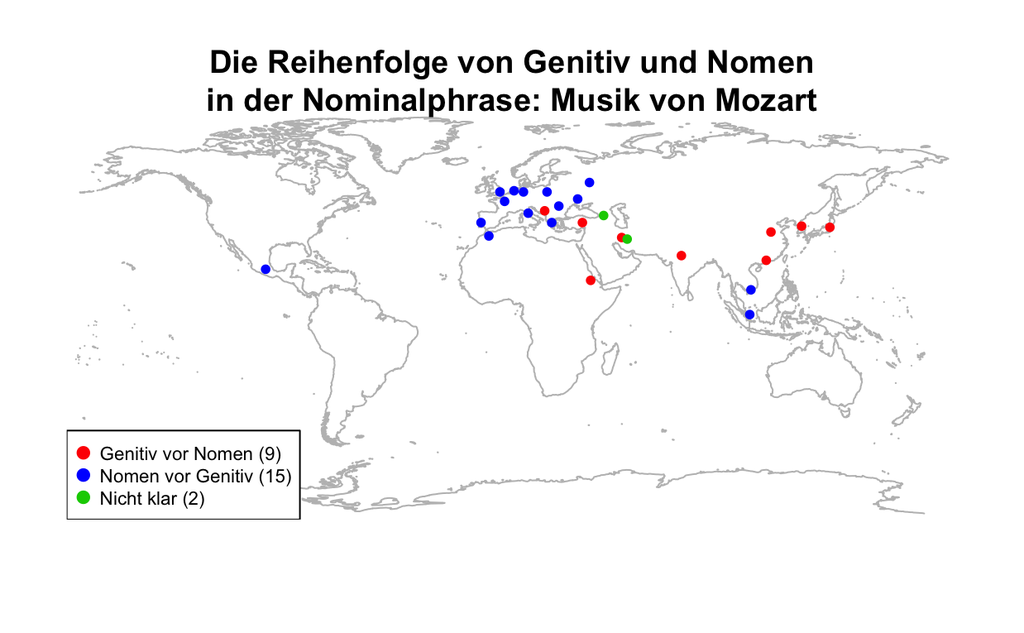

```r
title(main = "Die Reihenfolge von Genitiv und Nomen
in der Nominalphrase: Musik von Mozart")
legend ("bottomleft"
        , legend = myname
        , pch = MuMo
        , col = cols
        , cex = 0.7
        , pt.cex = 1.5)
```

Auf Karte 8 “Die Reihenfolge von Genitiv und Nomen in der Nominalphrase: Musik von Mozart” sind die Sprachen mit “Genitiv vor Nomen” mit roten Pünktchen markiert, mit blauen Pünktchen die Sprachen mit “Nomen vor Genitiv” und mit grünen Pünktchen die “nicht klaren” Sprachen.